# Simulation for PseudoBulk Benchmarking

Léopold Guyot

2025-07-04

# Idea

```r
library(scpdata)
library(scp)
library(SingleCellExperiment)
library(msqrob2)
library(iCOBRA)
library(UpSetR)
library(tidyverse)
```

# Simulation strategy

## Experimental Data

To generate our data, we will use the dataset obtained from Brunner et al. 2022. (Label-Free). We will isolate only one condition (Untreated). For this condition we compute for each protein; his mean log-intensity and his standard deviation

## Intensities modelling

Let $X_{ij}$ denote the log-intensity of protein $i$ in cell $j$.

We model the log-intensity as:

$$X_{ij} = \mu_i + \epsilon_{ij} + A^{\text{patient}}_i \cdot
\delta^{\text{patient}}_{i, p_j} + A^{\text{cell type}}_i \cdot
\delta^{\text{cell type}}_{i, c_j}
+ A^{\text{treatment}}_i \cdot \delta^{\text{treatment}}_i \cdot
\mathbb{I}_{t_j = 1}$$

Where:

- $\mu_i$: baseline log-intensity of protein $i$ obtained from experimental data
- $\epsilon_{ij} \sim \mathcal{N}(0, \sigma_i^2)$: residual noise obtained from experimental data
- $A^{\text{patient}}_i$: indicator if protein $i$ is affected by patient-specific shifts
- $A^{\text{patient}}_i$: indicator if protein $i$ is affected by cell type-specific shifts
- $A^{\text{treatment}}_i$: indicator if protein $i$ is affected by treatment
- $p_j \in \{1, \ldots, P\}$: patient identity of cell $j$
- $c_j \in \{1, \ldots, P\}$: cell type identity of cell $j$
- $t_j \in \{0,1\}$: treatment status of cell $j$ (1 = treated)
- $\delta^{\text{patient}}_{i, p} \sim \mathcal{N}(0, \sigma_{\text{patient}}^2)$: patient-specific shift for protein $i$ and patient $p$
- $\delta^{\text{cell type}}_{i, c} \sim \mathcal{N}(0, \sigma_{\text{cell type}}^2)$: cell type-specific shift for protein $i$ and cell type $p$
- $\delta^{\text{treatment}}_i \sim \mathcal{N}(0, \sigma_{\text{treatment}}^2)$: treatment effect for protein $i$
- $\mathbb{I}_{t_j = 1}$: indicator function equals 1 if cell $j$ is treated, 0 otherwise

### Missing Data Modelling

Each $X_{ij}$ is observed with probability $1 - \pi_i$, where:

$$M_{ij} \sim \text{Bernoulli}(\pi_i)$$

If $M_{ij} = 1$, then $X_{ij} = \text{NA}$.

Where $\pi_i$ is the experimentally observed missing rate of protein $i$ .

## Simulation parameters

```r
# number of patients
nPatient = 16

# Cells by patient/subtype
nCellPatientSub = 100


nCellTot = nPatient * nCellPatientSub

# Inter-patient variability
patientSD <- 1

# Prop of proteins shifted by patient effect

patientEffect <- 0.3

nCellTypePerPatient <- 5
nCellPerType <- nCellPatientSub / nCellTypePerPatient

cellTypeEffect <- 0.3       # proportion of proteins affected
cellTypeShiftSD <- 1        # effect size

# proportion of proteins affected by treatment
treatmentEffect <- 0.3

# treatment shift strength
treatmentStrength <- 1
```

## Experimental Data

Prepare base data obtained from Brunner et al. 2022: Single cell proteomics data acquired by the Mann Lab using a newly designed timsTOF instrument, referred to as timsTOF-SCP. The dataset contains quantitative information from single-cells blocked at 4 cell cycle stages: G1, G1-S, G2, G2-M. The data was acquired using a label-free sample preparation protocole combined to a data independent (DIA) acquisition mode.

```r
base <- scpdata::brunner2022()
```

```
## snapshotDate(): 2025-04-12
```

```
## see ?scpdata and browseVignettes('scpdata') for documentation
```

```
## downloading 1 resources
```

```
## retrieving 1 resource
```

```
## loading from cache
```

```r
sce <- getWithColData(base, "proteins")
sce <- sce[, colData(sce)$CellCycleStage == "UB"]
sce <- logTransform(sce) # log transform to obtain normal intensities distribution
sce <- sce[rowSums(!is.na(assay(sce))) > 1, ]
sce
```

```
## class: SingleCellExperiment
## dim: 2373 203
## metadata(0):
## assays(1): ''
## rownames(2373): UBA6_HUMAN SHOT1_HUMAN ... NS1BP_HUMAN S23IP_HUMAN
## rowData names(5): Protein.Group Protein.Ids Protein.Names Genes First.Protein.Description
## colnames(203):
##   D:\Andreas_Brunner\Projects\SingleCellProteomics\202109_WorkHere\SingleCells\SingleShots_RawData\20201010_TIMS04_Evo07_AnBr_1Cell_HeLa_UB_12_S3-B2_1_4101.d
##   D:\Andreas_Brunner\Projects\SingleCellProteomics\202109_WorkHere\SingleCells\SingleShots_RawData\20201010_TIMS04_Evo07_AnBr_1Cell_HeLa_UB_13_S3-B3_1_4102.d
##   ...
##   D:\Andreas_Brunner\Projects\SingleCellProteomics\202109_WorkHere\SingleCells\SingleShots_RawData\20201126_TIMS04_Evo07_SA_ADB_1cell_HeLa_UB_167_S2-H11_1_5178.d
##   D:\Andreas_Brunner\Projects\SingleCellProteomics\202109_WorkHere\SingleCells\SingleShots_RawData\20201126_TIMS04_Evo07_SA_ADB_1cell_HeLa_UB_78_S1-H6_1_5083.d
## colData names(14): File.Name Run ... RunID Label
## reducedDimNames(0):
## mainExpName: NULL
## altExpNames(0):
```

## Intensity distribution

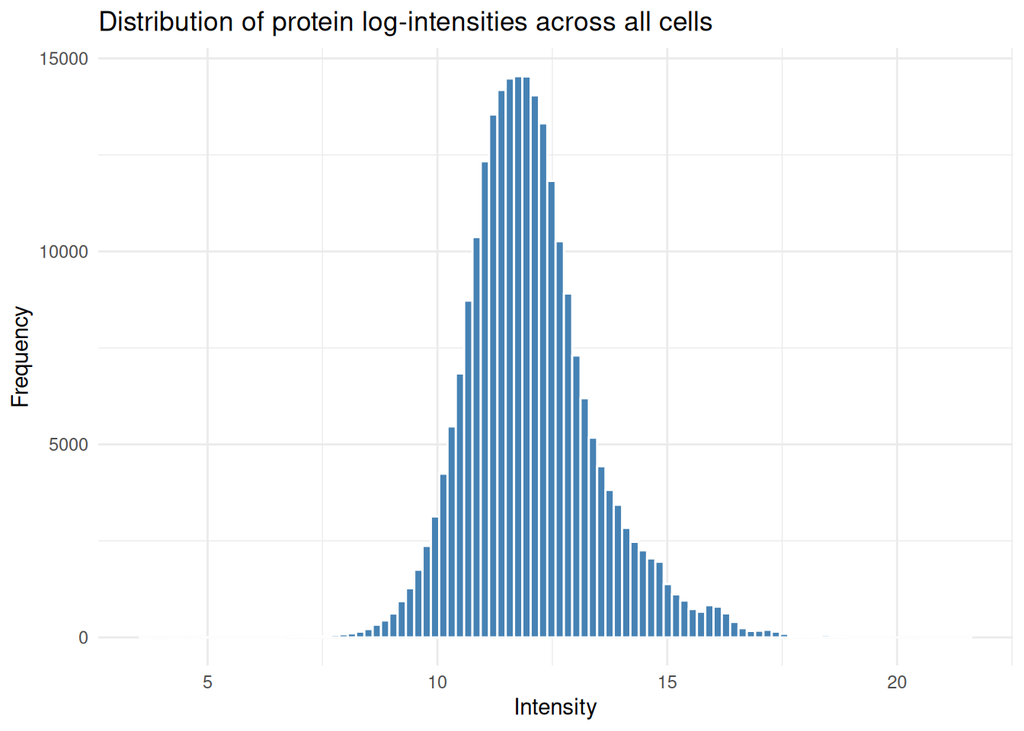

```r
int_mat <- assay(sce)
int_vec <- as.vector(int_mat)
int_vec <- int_vec[!is.na(int_vec)]
ggplot(data.frame(intensity = int_vec), aes(x = intensity)) +
  geom_histogram(bins = 100, fill = "steelblue", color = "white") +
  theme_minimal() +
  labs(title = "Distribution of protein log-intensities across all cells",
       x = "Intensity", y = "Frequency")
```

## Get log-intensities metrics

```r
protAssay <- as.data.frame(assay(sce))

# Compute metric
meanIntensity <- rowMeans(protAssay, na.rm = TRUE)
sdIntensity <- apply(protAssay, 1, sd, na.rm = TRUE)
pctMissing <- rowMeans(is.na(protAssay)) * 100

protMetrics <- data.frame(
  protNames = rownames(protAssay),
  meanIntensity = meanIntensity,
  sdIntensity = sdIntensity,
  pctMissing = pctMissing,
  stringsAsFactors = FALSE
)
head(protMetrics)
```

```
##               protNames meanIntensity sdIntensity pctMissing
## UBA6_HUMAN   UBA6_HUMAN      10.80805   0.3678057   95.56650
## SHOT1_HUMAN SHOT1_HUMAN      10.53306   0.5743521   76.35468
## ILVBL_HUMAN ILVBL_HUMAN      10.10614   0.8832194   97.04433
## VWA8_HUMAN   VWA8_HUMAN      10.73573   0.4490042   92.61084
## GTPBA_HUMAN GTPBA_HUMAN      10.13827   0.7263385   85.71429
## CNOT1_HUMAN CNOT1_HUMAN      11.17584   0.5817081   50.73892
```

## Intensities metrics distribution

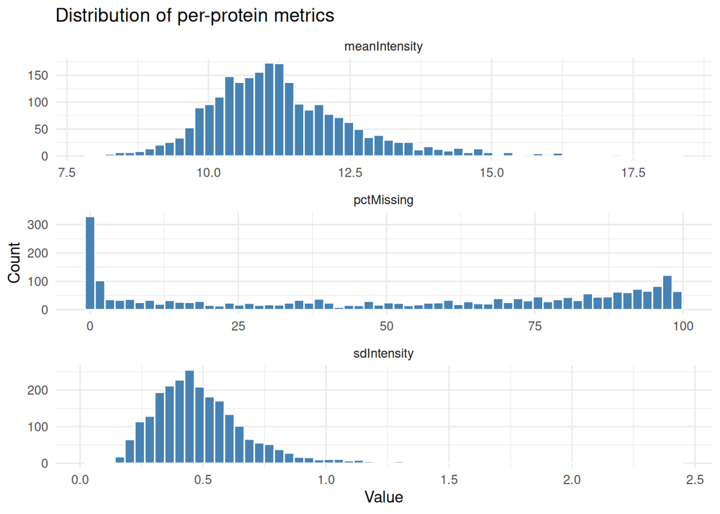

```r
protMetrics_long <- protMetrics %>%
  pivot_longer(cols = c(meanIntensity, sdIntensity, pctMissing),
               names_to = "metric",
               values_to = "value")

ggplot(protMetrics_long, aes(x = value)) +
  geom_histogram(bins = 60, fill = "steelblue", color = "white") +
  facet_wrap(~ metric, scales = "free", ncol = 1) +
  theme_minimal() +
  labs(title = "Distribution of per-protein metrics",
       x = "Value", y = "Count")
```

## Simulation (patient and subtype pattern)

```r
mu <- protMetrics$meanIntensity
proteinNames <- protMetrics$protNames
residualSD <- protMetrics$sdIntensity
missingProb <- protMetrics$pctMissing/100
nProt <- length(mu)
```

```r
# Initialize matrix
simMatrix <- matrix(NA, nrow = nProt, ncol = nCellTot)
rownames(simMatrix) <- proteinNames
cellIds <- paste0("P", rep(1:nPatient, each = nCellPatientSub), "_C", 1:nCellTot)
colnames(simMatrix) <- cellIds
```

```r
nPatientShiftProt <- floor(patientEffect * nProt)
patientShiftProteins <- sample(proteinNames, nPatientShiftProt)
```

```r
# Prepare colData dataframe

patients <- sub("_.*", "", colnames(simMatrix))

colData <- data.frame(
  cellId = colnames(simMatrix),
  patient = patients,
  patientShift = numeric(nCellTot),
  stringsAsFactors = FALSE
)

cellTypes <- character(nCellTot)
for (i in 1:nPatient) {
  for (j in 1:nCellTypePerPatient) {
    startIdx <- ((i - 1) * nCellPatientSub) + ((j - 1) * nCellPerType) + 1
    endIdx <- startIdx + nCellPerType - 1
    cellTypes[startIdx:endIdx] <- paste0("Type", j)
  }
}

colData$cellType <- cellTypes
```

```r
cellCounter <- 1

# Simulate
for (i in 1:nPatient) {
  patientShift <- numeric(nProt)
  names(patientShift) <- proteinNames
  patientShift[patientShiftProteins] <- rnorm(nPatientShiftProt, mean = 0, sd = patientSD)

  for (k in 1:nCellPatientSub) {
      cellIndex <- cellCounter
      colData$patientShift[cellIndex] <- list(patientShift)
      simMatrix[, cellIndex] <- rnorm(nProt, mean = mu, sd = residualSD) + patientShift

      cellCounter <- cellCounter + 1
    }
  }
```

## Simulate data missingness

```r
# Add missing values

for (p in seq_len(nProt)) {
  missing <- runif(nCellTot) < missingProb[p]
  simMatrix[p, missing] <- NA
}
```

Should the sampling of shifted proteins be the same for all patients/celltypes?

## Create the SingleCellExperiment object

```r
simSCE <- SingleCellExperiment(assays = SimpleList(simMatrix),
                     rowData = rowData(sce),
                     colData = colData)
simSCE
```

```
## class: SingleCellExperiment
## dim: 2373 1600
## metadata(0):
## assays(1): ''
## rownames(2373): UBA6_HUMAN SHOT1_HUMAN ... NS1BP_HUMAN S23IP_HUMAN
## rowData names(5): Protein.Group Protein.Ids Protein.Names Genes First.Protein.Description
## colnames(1600): P1_C1 P1_C2 ... P16_C1599 P16_C1600
## colData names(4): cellId patient patientShift cellType
## reducedDimNames(0):
## mainExpName: NULL
## altExpNames(0):
```

## Add cell type effect

```r
nCellTypeShiftProt <- floor(cellTypeEffect * nProt)
cellTypeShiftProteins <- sample(proteinNames, nCellTypeShiftProt)

rowData(simSCE)$cellTypeAffected <- proteinNames %in% cellTypeShiftProteins
exprMat <- assay(simSCE)

# For each patient
for (i in 1:nPatient) {
  for (j in 1:nCellTypePerPatient) {
    thisCellType <- paste0("Type", j)
    cellsIdx <- which(colData$patient == paste0("P", i) &
                       colData$cellType == thisCellType)

    # Define cell-type-specific shift (same for all cells of that type)
    shiftVec <- numeric(nProt)
    names(shiftVec) <- proteinNames
    shiftVec[cellTypeShiftProteins] <- rnorm(nCellTypeShiftProt, mean = 0, sd = cellTypeShiftSD)

    # Apply shift to these cells
    exprMat[cellTypeShiftProteins, cellsIdx] <- exprMat[cellTypeShiftProteins, cellsIdx] +
      shiftVec[cellTypeShiftProteins]
  }
}

# Save back to SCE
assay(simSCE) <- exprMat
```

## Add treatment effect

```r
# Initialize treatment vector
treatment_vector <- character(ncol(simSCE))
names(treatment_vector) <- colnames(simSCE)

# Get colData
cd <- colData(simSCE)

# Loop over each patient-subtype group
for (p in unique(cd$patient)) {
    # Find cell indices in this group
    group_cells <- which(cd$patient == p)

    # Shuffle and assign 50% treated, 50% control
    n_group <- length(group_cells)
    n_treat <- floor(n_group / 2)

    treated_cells <- sample(group_cells, size = n_treat)
    control_cells <- setdiff(group_cells, treated_cells)

    treatment_vector[treated_cells] <- "treated"
    treatment_vector[control_cells] <- "control"
  }

# Assign to colData
colData(simSCE)$treatment <- treatment_vector
```

```r
# Select affected proteins
nProt <- nrow(simSCE)
proteinNames <- rownames(simSCE)
nAffected <- floor(treatmentEffect * nProt)
affected_proteins <- sample(proteinNames, size = nAffected, replace = FALSE)

# Simulate shift per affected protein
treatment_shift_vec <- numeric(nProt)
names(treatment_shift_vec) <- proteinNames
treatment_shift_vec[affected_proteins] <- rnorm(nAffected, mean = 0, sd = treatmentStrength)

# Modify assay
exprMat <- assay(simSCE)
treated_cells <- colData(simSCE)$treatment == "treated"

# Apply shift: add the same shift for each affected protein across treated cells
exprMat[affected_proteins, treated_cells] <- exprMat[affected_proteins, treated_cells] +
  treatment_shift_vec[affected_proteins]

# Save modified matrix back
assay(simSCE) <- exprMat

rowData(simSCE)$treatmentAffected <- rownames(simSCE) %in% affected_proteins
rowData(simSCE)$treatmentShift <- treatment_shift_vec
```

```r
simSCE
```

```
## class: SingleCellExperiment
## dim: 2373 1600
## metadata(0):
## assays(1): ''
## rownames(2373): UBA6_HUMAN SHOT1_HUMAN ... NS1BP_HUMAN S23IP_HUMAN
## rowData names(8): Protein.Group Protein.Ids ... treatmentAffected treatmentShift
## colnames(1600): P1_C1 P1_C2 ... P16_C1599 P16_C1600
## colData names(5): cellId patient patientShift cellType treatment
## reducedDimNames(0):
## mainExpName: NULL
## altExpNames(0):
```

## Plot new distribution of log-intensities

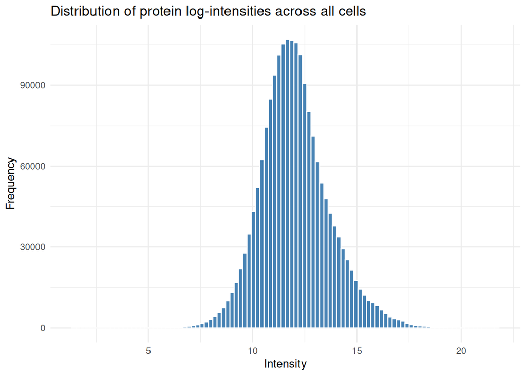

```r
int_mat <- assay(simSCE)
int_vec <- as.vector(int_mat)
int_vec <- int_vec[!is.na(int_vec)]
ggplot(data.frame(intensity = int_vec), aes(x = intensity)) +
  geom_histogram(bins = 100, fill = "steelblue", color = "white") +
  theme_minimal() +
  labs(title = "Distribution of protein log-intensities across all cells",
       x = "Intensity", y = "Frequency")
```

## Apply scplainer

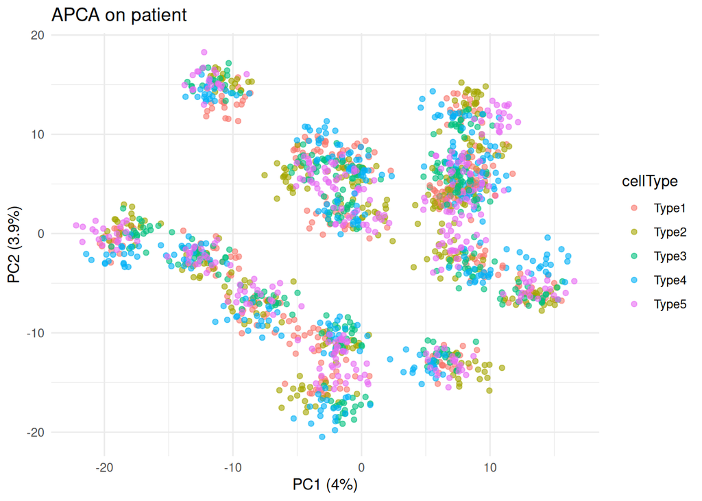

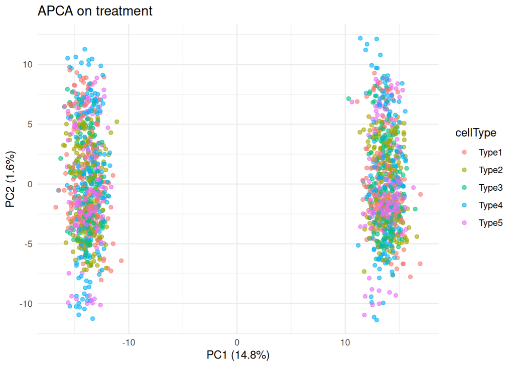

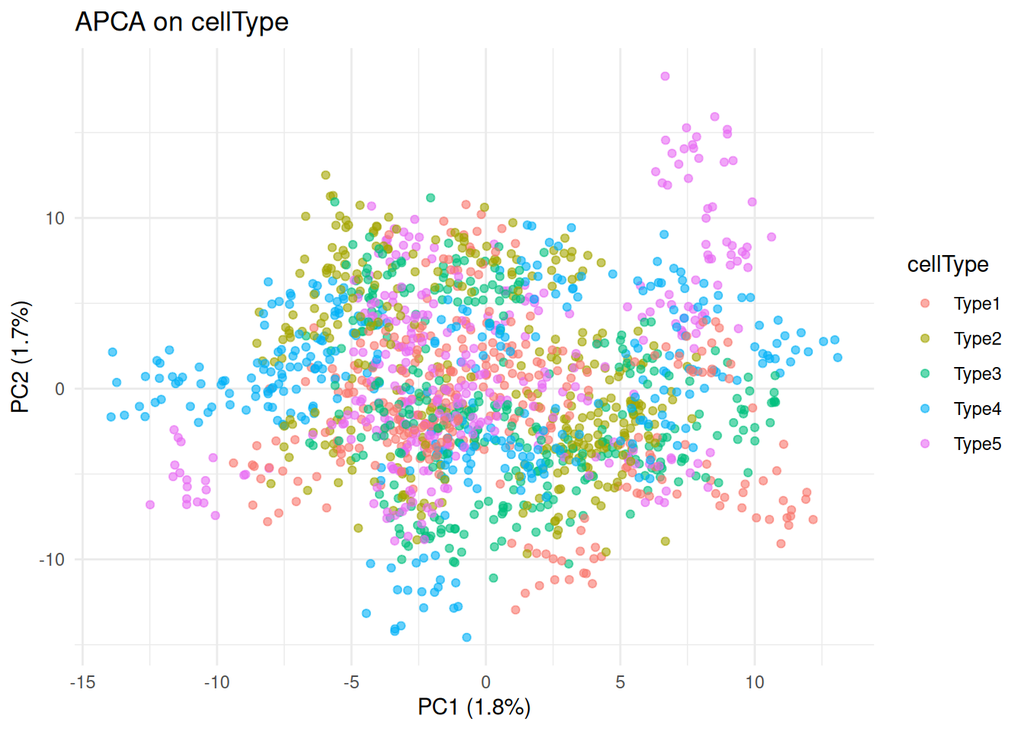

```r
scpSIM <- scpModelWorkflow(simSCE, formula = ~ 1 + patient + treatment + cellType, verbose = FALSE)
scpRes <- scpDifferentialAnalysis(
    scpSIM,
    contrasts = list(c("treatment", "control", "treated"))
)[[1]]
pca <- scpComponentAnalysis(scpSIM, method = "APCA", residuals = FALSE, unmodelled = FALSE)
colData(scpSIM)$cell <- colData(scpSIM)$cellId
bySamplePCs <- scpAnnotateResults(
    pca$bySample, colData(scpSIM), by = "cell"
)
scpComponentPlot(bySamplePCs, pointParams = list(
        aes(colour = cellType),
        alpha = 0.6
    ))
```

## Apply msqrob2

```r
L <- makeContrast("treatmenttreated=0", parameterNames = c("treatmenttreated"))
```

```r
msqSIM <- suppressWarnings(msqrob(simSCE, formula = ~ (1 | patient) + treatment + cellType))
msqRes <- rowData(hypothesisTest(object = msqSIM, contrast = L))$treatmenttreated
```

## Apply PseudoBulk + msqrob2

```r
aggregate_se <- function(se, group_by_cols, fun = mean) {
    if (!all(group_by_cols %in% colnames(colData(se)))) {
        stop("Some specified group_by_cols do not exist in colData.")
    }
    colData(se)$Group <- apply(colData(se)[, group_by_cols, drop = FALSE], 1, paste, collapse = "_")
    group_factor <- factor(colData(se)$Group)
    assay_matrix <- assay(se)

    # Aggregate assay matrix by group_factor levels order
    grouped_indices <- split(seq_along(group_factor), group_factor)
    levels_group <- levels(group_factor)  # factor levels in order
    aggregated_assay <- do.call(cbind, lapply(levels_group,
                                              function(g) {
                                                  idx <- grouped_indices[[g]]
                                                  apply(assay_matrix[, idx, drop = FALSE], 1, fun, na.rm = TRUE)
                                              }))
    new_colData <- colData(se) %>%
        as.data.frame() %>%
        group_by(Group) %>%
        summarise(across(all_of(group_by_cols), dplyr::first), .groups = "drop") %>%
        as.data.frame()
    # Reorder new_colData rows to match factor levels
    new_colData <- new_colData[match(levels_group, new_colData$Group), ]
    rownames(new_colData) <- new_colData$Group
    new_se <- SummarizedExperiment(assays = list(aggregated_assay),
                                   colData = new_colData,
                                   rowData = rowData(se))
    return(new_se)
}


pbSIM <- aggregate_se(simSCE, c("patient", "treatment", "cellType"), fun = mean)
pbSIM <- suppressWarnings(msqrob(pbSIM, ~ 1 + patient + treatment + cellType))
pbRes <- rowData(hypothesisTest(object = pbSIM, contrast = L))$treatmenttreated
```

# Get FDR curves

```r
# Extract p-values from each result
pval_pb <- pbRes[, "pval", drop = FALSE]
colnames(pval_pb) <- "PBmsqrob2"

pval_msq <- msqRes[, "pval", drop = FALSE]
colnames(pval_msq) <- "msqrob2"

pval_scp <- as.data.frame(scpRes[, c("feature", "pvalue")])
colnames(pval_scp) <- c("feature", "scplainer")
rownames(pval_scp) <- pval_scp$feature
pval_scp$feature <- NULL

# Merge all three by rownames (feature names)
tmp1 <- merge(pval_pb, pval_msq, by = "row.names", all = TRUE)
rownames(tmp1) <- tmp1$Row.names
tmp1$Row.names <- NULL

combined_pvals <- merge(tmp1, pval_scp, by = "row.names", all = TRUE)
rownames(combined_pvals) <- combined_pvals$Row.names
combined_pvals$Row.names <- NULL

# Extract adjusted p-values from each result
padj_pb <- pbRes[, "adjPval", drop = FALSE]
colnames(padj_pb) <- "PBmsqrob2"

padj_msq <- msqRes[, "adjPval", drop = FALSE]
colnames(padj_msq) <- "msqrob2"

padj_scp <- as.data.frame(scpRes[, c("feature", "padj")])
colnames(padj_scp) <- c("feature", "scplainer")
rownames(padj_scp) <- padj_scp$feature
padj_scp$feature <- NULL

# Merge all three by rownames (feature names)
tmp_padj <- merge(padj_pb, padj_msq, by = "row.names", all = TRUE)
rownames(tmp_padj) <- tmp_padj$Row.names
tmp_padj$Row.names <- NULL

combined_padj <- merge(tmp_padj, padj_scp, by = "row.names", all = TRUE)
rownames(combined_padj) <- combined_padj$Row.names
combined_padj$Row.names <- NULL
```

```r
truth <- data.frame(isTreated = rowData(simSCE)$treatmentAffected,
                    row.names = rownames(rowData(simSCE))
                    )
```

```r
cobData <- COBRAData(
  pval = combined_pvals,
  padj = combined_padj,
  truth = truth
)

perfRes <- calculate_performance(cobradata = cobData,
                      binary_truth = "isTreated") %>%
    fdrtpr() %>%
    mutate(thr = as.numeric(sub("thr", "", thr)))
```

```
## binary_truth column is logical, converting to numeric (0/1)
```

```
## Object up to date
```

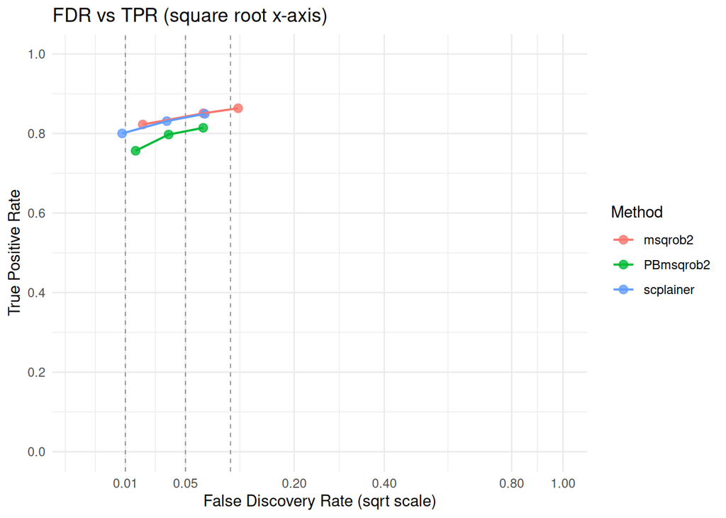

```r
plot <- ggplot(perfRes, aes(x = FDR, y = TPR, color = method)) +
    geom_vline(
        xintercept = c(0.01, 0.05, 0.1),
        linetype = "dashed", color = "grey50", size = 0.3
    ) +
    geom_point(size = 2.5, alpha = 0.8) +
    geom_line(size = 0.7) +
    scale_x_continuous(
        trans = "sqrt",
        limits = c(0, 1),
        breaks = c(0.01, 0.05, 0.2, 0.4, 0.8, 1),
        labels = scales::label_number()
    ) +
    scale_y_continuous(
        limits = c(0, 1),
        breaks = seq(0, 1, 0.2)
    ) +
    theme_minimal() +
    labs(
        title = "FDR vs TPR (square root x-axis)",
        x = "False Discovery Rate (sqrt scale)",
        y = "True Positive Rate",
        color = "Method"
    )
plot
```

## Upset plot

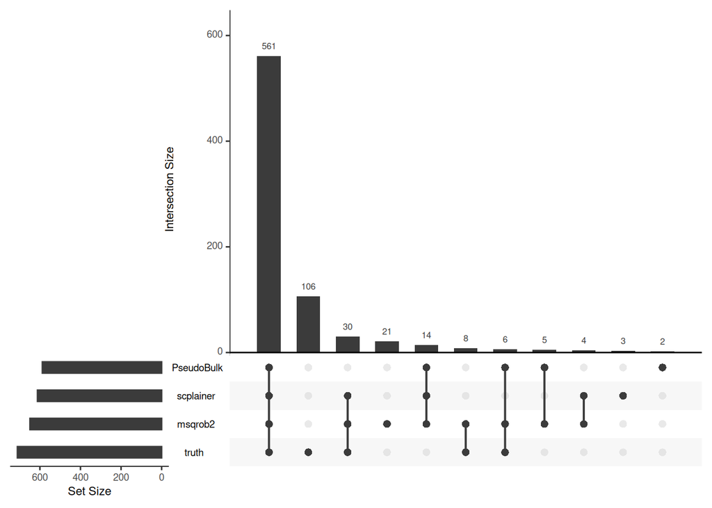

```r
scpFeatures <- scpRes %>%
    as.data.frame() %>%
    filter(padj <= 0.05) %>%
    pull(feature)

msqFeatures <- msqRes %>%
    as.data.frame() %>%
    filter(adjPval <= 0.05) %>%
    rownames()

pbFeatures <- pbRes %>%
    as.data.frame() %>%
    filter(adjPval <= 0.05) %>%
    rownames()

truthFeatures <- rowData(simSCE) %>%
    as.data.frame() %>%
    filter(treatmentAffected) %>%
    rownames()

listUpSet <- list("scplainer" = scpFeatures,
                  "msqrob2" = msqFeatures,
                  "PseudoBulk" = pbFeatures,
                  "truth" = truthFeatures)
upset(fromList(listUpSet), order.by = "freq")
```